# Lecture_04.expression.analysis.JupyterHub.live

## Advanced Graphics and Data Visualization in R

## Lecture 04: Expressing expression data

## 0.1.0 An overview of Advanced Graphics and Data Visualization in R

**"Advanced Graphics and Data Visualization in R"** is brought to you by the Centre for the Analysis of Genome Evolution & Function's (CAGEF) bioinformatics training initiative. This CSB1021 was developed to enhance the skills of students with basic backgrounds in R by focusing on available philosophies, methods, and packages for plotting scientific data. While the datasets and examples used in this course will be centred on SARS-CoV-2 epidemiological and genomic data, the lessons learned herein will be broadly applicable.

This lesson is the fourth in a 6-part series. The aim for the end of this series is for students to recognize how to import, format, and display data based on their intended message and audience. The format and style of these visualizations will help to identify and convey the key message(s) from their experimental data.

The structure of the class is a **code-along style** in Jupyter notebooks. At the start of each lecture, skeleton versions of the lecture will be provided for use on the [University of Toronto Jupyter Hub](https://jupyter.utoronto.ca/hub/login) so students can program along with the instructor.

## 0.2.0 Lecture objectives

This week will focus on standard visualizations of expression data. While our prior topics have focused on making visualizations that are applicable broadly to many types of data, a number of this week's visualizations are used mainly on multi-dimensional data from experiments like RNAseq.

At the end of this lecture you will have covered the following topics

1. Visualizing flowcharts and workflows
2. Scatterplot variants of RNAseq data
3. Colour gradient visualizations aka heatmaps
4. RNAseq data analysis with `goseq`
5. Visualizing relationships between samples

## 0.3.0 A legend for text format in Jupyter markdown

`grey background` - a package, function, code, command or directory. Backticks are also use for in-line code.  
*italics* - an important term or concept or an individual file or folder  
**bold** - heading or a term that is being defined  
blue text - named or unnamed hyperlink

## 0.4.0 Data used in this lesson

Today's datasets will focus on differential expression analysis. The basic visualizations of this data after it has already been processed by packages like `DESeq2`.

## 0.4.1 Dataset 1: Lecture04_sankey_data.csv

This is an example dataset used for building a Sankey diagram. It builds a theoretical workflow for RNAseq analysis and visualization within a manuscript. What is a Sankey diagram? We'll find out!

## 0.4.2 Dataset 2: Blanco-Melo2020Cell.Supp1.xlsx

This is an RNAseq dataset comparison for infection of multiple cell types with pathogens like SARS-CoV-2, SARS-CoV-1, MERS-CoV, RSV (respiratory syncytial virus), IAV (influenza A virus) and HPIV3 (human parainfluenze virus type 3) published in *Cell* doi: 10.1016/j.cell.2020.04.026

## 0.4.3 Dataset 3: Blanco-Melo2020_Supp_Data_4.xlsx

This is an RNAseq dataset comparison for infection of human alveolar adenocarcinoma (A549) cells with and without influenza A virus (IAV) published on *bioRxiv* doi: https://doi.org/10.1101/2020.03.24.004655

## 0.4.4 Dataset 4: Lecture04.RData

A saved file with a final dataset we look at with our visualizations of dot plots.

## 0.5.0 Packages used in this lesson

`repr`- a package useful for altering some of the attributes of objects related to the R kernel.

`tidyverse` which has a number of packages including `dplyr`, `tidyr`, `stringr`, `forcats` and `ggplot2`

`viridis` helps to create color-blind palettes for our data visualizations

`networkD3`, `gghighlight`, `ggrepel`, and `UpSetR` are used in building some of our visualizations including flowcharts, and upset plots.

`goseq`, and `org.Hs.eg.db` are packages that will help us perform some basic Gene Ontology (GO) annotations with our data.

```r
# Install these packages onto JupyterHub
# install.packages("networkD3")
# install.packages("gghighlight")
# install.packages("UpSetR")

# # Some packages can be installed via Bioconductor
# if (!requireNamespace("BiocManager", quietly = TRUE))
#     install.packages("BiocManager")

# BiocManager::install("goseq")
# BiocManager::install("org.Hs.eg.db")
```

```r
# Packages to help tidy our data
library(tidyverse)
library(readxl)

# Packages for the graphical analysis section
library(repr)
library(viridis)

# Lecture 04 visualization packages
library(networkD3)
library(gghighlight)
library(ggrepel)
library(UpSetR)

# GO term analysis packages
library(goseq)
library(org.Hs.eg.db)
```

## 1.0.0 Working with large amounts of data

Until this point, the data sets we have used in lecture have been relatively simple epidemiological information. All of our observations are values like new cases or vaccinated individuals tied to dates or time periods. Whereas most of our observations were connected in some linear fashion the data we examine today will have tens of thousands of observations, each representing a different gene!

Given the complexity of our data, we will discuss ways to sort, partition, visualize and interpret it.

## 1.1.0 Where does RNAseq data come from?

Many of you may be familiar with the idea of RNAseq data. It begins in the real world (or at the bench) with individuals/groups/conditions compared against a control state. Biological samples can be collected in time series or at a single endpoint. Every experimental conditions should have a matching control or baseline profile for comparison, not to mention biological replicates!

After collecting your samples you still need to prepare and sequence your libraries, check your data quality, trim reads, map them to a transcriptome, estimate/normalize the expression of genes within each library and *then* compare the expression between libraries/samples to determine if there are transcriptional differences! All of these steps are beyond this class BUT if you plan on working with transcriptomes, you'll eventually encounter this process. Today we'll jump the line and work directly with differential expression (DE) data. That means we'll be at the bottom right corner of the following diagram AKA, the end of the pipeline.

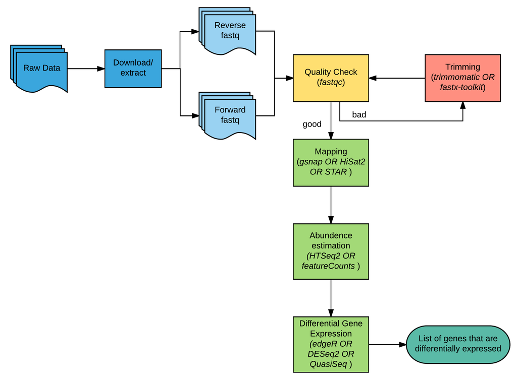

*Image from Bioinformatics Workbook: [RNA Sequencing Analysis](https://bioinformaticsworkbook.org/dataAnalysis/RNA-Seq/RNA-SeqIntro/RNAseq-using-a-genome.html#gsc.tab=0)*

## 1.2.0 Use a Sankey diagram to illustrate your workflow

Sankey diagrams are named after Irish Captain Matthew Henry Phineas Riall Sankey, who first presented this type of visualization in 1898 to convey the energy efficiency of a steam engine!

With larger sets of data across multiple experiments, it can sometimes be helpful to use a Sankey diagram to explain the connection between different aspects of your samples. The key attribute of the Sankey diagram is that the width of a connection (flow) is proportional to the quantity represented. So the Sankey diagram is a flow diagram that also visually quantifies the dynamics of the relationships in your diagram. Think of it much like a stacked bar chart that can split or join with other bars at each connection.

A useful package to generate Sankey diagrams is `networkD3` using the `sankeyNetwork()` function. To generate a Sankey diagram, you need information on two variables with a third optional one:

- `source`: a starting point or for your flow
- `target`: the end point of your flow
- `value`: the number that will represent the width of your flow. Usually some quantity of contribution but this can also be an optional variable.

We'll find a pre-made table to that describes a theoretical RNAseq workflow based in the datasets we'll be working with today. Some sections have been compressed for brevity but we'll find all of that information in `./data/Lecture04_sankey_data.csv`. Let's begin by reading it in.

```r
# Read in our Sankey diagram in /data/Lecture04_sankey_data.csv

sankey_info.df <- read_csv("./data/Lecture04_sankey_data.csv")

# Check the structure
str(sankey_info.df)

# Look a few rows
head(sankey_info.df)
```

```
tibble [24 x 3] (S3: spec_tbl_df/tbl_df/tbl/data.frame)
 $ source: chr [1:24] "CoV" "CoV" "IVS" "RSV" ...
 $ target: chr [1:24] "A549" "NHBE" "A549" "A549" ...
 $ value : num [1:24] 0.25 0.25 0.25 0.25 0.7 0.2 0.4 0.4 0.15 0.15 ...
 - attr(*, "spec")=
  .. cols(
  ..   source = col_character(),
  ..   target = col_character(),
  ..   value = col_double()
  .. )
```

A tibble: 6 × 3

| source <chr> | target <chr> | value <dbl> |
| --- | --- | --- |
| CoV | A549 | 0.25 |
| CoV | NHBE | 0.25 |
| IVS | A549 | 0.25 |
| RSV | A549 | 0.25 |
| A549 | RNAseq | 0.70 |
| NHBE | RNAseq | 0.20 |

## 1.2.1 Convert your flow data frame into a node data frame

Although our data frame `sankey_info.df` contains the information about our connections, the `networkD3` package requires some mapping of the nodes within our data. Each unique source and target will be counted as a node and we'll save that information into `sankey_nodes.df`.

```r
# Combine our source and target lists, then take the unique set and put that into the "name" vector.

sankey_nodes.df <- data.frame(name=c(as.character(sankey_info.df$source), # Location of our source nodes
                                     as.character(sankey_info.df$target)) %>%  # Location of our target nodes
                              unique() # Generate the unique combination of the two sets
                             )
# Look at the structure, it's just a list of the nodes
str(sankey_nodes.df)
```

```
'data.frame':	18 obs. of  1 variable:
 $ name: chr  "CoV" "IVS" "RSV" "A549" ...
```

## 1.2.2 Map your node names back to your source and target data with `match()`

Now that we have our nodes information stored basically as an identification number, we have to map it back to `sankey_info.df`. This is essentially like working with a factor that spans two columns instead of just one. To accomplish the mapping, we'll use the `match()` method.

Note that our node information must be 0-indexed! R uses an indexing scheme that begins at 1 so we'll need to offset that information that we generate as well.

```r
# Add our sankey_nodes.df as index information that maps between it and `sankey_info.df`
sankey_info.df <-
sankey_info.df  %>% mutate(IDsource = match(.$source, sankey_nodes.df$name) - 1,
                           IDtarget = match(.$target, sankey_nodes.df$name) - 1) # nodes must be 0-indexed

sankey_info.df

sankey_nodes.df
```

A spec_tbl_df: 24 × 5

| source <chr> | target <chr> | value <dbl> | IDsource <dbl> | IDtarget <dbl> |
| --- | --- | --- | --- | --- |
| CoV | A549 | 0.25 | 0 | 3 |
| CoV | NHBE | 0.25 | 0 | 4 |
| IVS | A549 | 0.25 | 1 | 3 |
| RSV | A549 | 0.25 | 2 | 3 |
| A549 | RNAseq | 0.70 | 3 | 5 |
| NHBE | RNAseq | 0.20 | 4 | 5 |
| RNAseq | DESeq2 | 0.40 | 5 | 6 |
| RNAseq | Read coverage | 0.40 | 5 | 8 |
| DESeq2 | Volcano plots | 0.15 | 6 | 11 |
| DESeq2 | Heatmaps | 0.15 | 6 | 10 |
| DESeq2 | MA plots | 0.15 | 6 | 9 |
| DESeq2 | GO term analysis | 0.15 | 6 | 7 |
| DESeq2 | Prinicipal component analysis | 0.15 | 6 | 13 |
| GO term analysis | Network diagrams | 0.15 | 7 | 12 |
| Read coverage | Figure 1 | 0.20 | 8 | 14 |
| MA plots | Figure 2 | 0.15 | 9 | 15 |
| Heatmaps | Figure 2 | 0.08 | 10 | 15 |
| Heatmaps | Figure 3 | 0.08 | 10 | 16 |
| Read coverage | Figure 4 | 0.20 | 8 | 17 |
| Volcano plots | Figure 1 | 0.08 | 11 | 14 |
| Volcano plots | Figure 4 | 0.08 | 11 | 17 |
| Network diagrams | Figure 1 | 0.08 | 12 | 14 |
| Network diagrams | Figure 2 | 0.08 | 12 | 15 |
| Prinicipal component analysis | Figure 3 | 0.15 | 13 | 16 |

A data.frame: 18 × 1

| name <chr> |
| --- |
| CoV |
| IVS |
| RSV |
| A549 |
| NHBE |
| RNAseq |
| DESeq2 |
| GO term analysis |
| Read coverage |
| MA plots |
| Heatmaps |
| Volcano plots |
| Network diagrams |
| Prinicipal component analysis |
| Figure 1 |
| Figure 2 |
| Figure 3 |
| Figure 4 |

## 1.2.3 Build your Sankey diagram with `sankeyNetwork()`

Now that we have our two necessary data frames, we can build our Sankey diagram with the `sankeyNetwork()` function. This function has a few parameters that we'll want to set:

- `Links`: the location of our source/target relationship information (`sankey_info.df`).
- `Nodes`: the listing of nodes in our diagram (`sankey_nodes.df`).
- `Source`: the name of the source column.
- `Target`: the name of our target column.
- `Value`: the name of our "optional" value to build the width of flows.
- `NodeID`: the names of our nodes.

There are an additional number of parameters that allow you to play with the visualization of this diagram including:

- `colourScale`: categorical colour of your node. Works together with...
- `NodeGroup`: for colouring your nodes based on an extra column in `Nodes`.
- `LinkGroup`: for colouring your links based on an extra column in `Links`.
- `nodeWidth`: the numeric width of each node.

For more information on these parameters and others, you can go [here](https://www.rdocumentation.org/packages/networkD3/versions/0.4/topics/sankeyNetwork)

```r
# Build the Sankey diagram with all of our information

sankeyNetwork(Links = sankey_info.df, # Where is the "edge" information
              Nodes = sankey_nodes.df, # Where is the "node" information
              Source = "IDsource", # Where are the source node labels
              Target = "IDtarget", # Where are the target node labels
              Value = "value", # What value do we assign to the relationships/edges
              NodeID = "name", # Where are the labels for the nodes stored?
              sinksRight = TRUE, # Push the nodes to the right
              fontSize = 10)
```

## 1.3.0 What does differential expression data look like?

Digging down into your DE results, with the human genome, you are looking to identify trends in gene expression differences across 43,000 potential transcripts sequences - only half of which produce proteins. You can imagine that opening up a tabular file of that size could take a bit of time.

For each DE experiment there are a number of values generated. In a popular package like `DESeq2` you will typically find:

| Variable | Description |
| --- | --- |
| Gene name | The names of your genes which may be in different formats like Entrez ID, Ensembl, or gene symbol |
| Base mean | Average of the normalized counts values, accounting for size factors, taken over all samples (and or replicates) |
| Log$_{2}$ fold-change | The effect size estimate - how much your gene's expression has changed from control/base conditions |
| Log fold-change SE | An estimate of effect size uncertainty |
| p-value | Hypothesis test against H$_{0}$ that no difference exists between sample groups |
| adjusted p-value | An adjusted p-value after taking into account multiple testing between groups/samples |

You can find more information on working with the `DESeq2` package [here](https://bioc.ism.ac.jp/packages/2.14/bioc/vignettes/DESeq2/inst/doc/beginner.pdf)

## 1.4.0 You can examine data on many scales

Once we have a set of data we can examine it at many resolutions:

1. Compare all genes within a sample and across samples
2. Compare DE in a subset of genes within a sample and across samples
3. Compare DE results based on gene function

Let's explore these different aspects and the kind of plots we can generate to accomodate the size of our data set. First, however, we need to find a useful data set to work with.

## 1.5.0 Use the `readxl` library to open your .xlsx files

We've briefly touched on using this package in `Lecture 01` to help read our Microsoft Excel-based data. Today's data set from Blanc-Melo et al. (Cell 2020), comes to us in the form of an excel file. Let's use some of the tools from this package to help open up our data file. We'll start by peeking at how many sheets there are using `excel_sheets()`.

```r
# What are the sheets to open in our data set?
excel_sheets("./data/Blanco-Melo2020Cell.Supp1.xlsx")
```

1. 'Legend'

2. 'DESeq2_Results'

## 1.5.1. Open each sheet separately with `read_excel()`

Now that we can see there are two sheets in our data, we can assign each one to a different data frame using the `read_excel()` command which contains the parameter `sheet`. We can use this to determine which sheet to load either based on it's position (integer) or it's name as specified by `excel_sheets()`.

```r
# Assign our legend
blanco_legend.df <- read_excel("./data/Blanco-Melo2020Cell.Supp1.xlsx", sheet = 1)

# Assign our data
blanco_data.df <- read_excel("./data/Blanco-Melo2020Cell.Supp1.xlsx", sheet = 2)

str(blanco_legend.df)
str(blanco_data.df)
```

```
tibble [20 x 3] (S3: tbl_df/tbl/data.frame)
 $ Field      : chr [1:20] "SARS-CoV-2(A549)_L2FC" "SARS-CoV-1_L2FC" "MERS-CoV_L2FC" "RSV_L2FC" ...
 $ Explanation: chr [1:20] "Fold expresion change Infected vs Control (logarithmic scale to base 2)" "Fold expresion change Infected vs Control (logarithmic scale to base 2)" "Fold expresion change Infected vs Control (logarithmic scale to base 2)" "Fold expresion change Infected vs Control (logarit…
 $ Notes      : chr [1:20] "SARS-CoV-2 infection (A549 cells, MOI: 2, 24hpi)" "SARS-CoV-1 infection (MRC5 cells, MOI: 3, 24hpi Data from: GSE56192)" "MERS-CoV infection (MRC5 cells, MOI: 3, 24hpi Data from: GSE56192)" "RSV (A549 cells, MOI: 2, 24hpi)" ...
tibble [23,710 x 21] (S3: tbl_df/tbl/data.frame)
 $ GeneName                              : chr [1:23710] "IFNL1" "IFNL2" "IFNL3" "IFNB1" ...
 $ SARS-CoV-1_L2FC                       : num [1:23710] 0 0 0 0 0 ...
 $ IAV_L2FC                              : num [1:23710] 1.37 1.379 1.815 0.468 0.24 ...
 $ MERS-CoV_L2FC                         : num [1:23710] 0 0.125 0 0 0.125 ...
 $ HPIV3_L2FC                            : num [1:23710] 7.84 6.84 6.23 6.44 2.62 ...
 $ RSV_L2FC                              : num [1:23710] 7.14 4.84 4.83 4.86 0 ...
 $ SARS-CoV-2(Calu-3)_L2FC               : num [1:23710] 7.24 7.88 7.47 8.7 3.33 ...
 $ SARS-CoV-2(A549)_L2FC                 : num [1:23710] 0 0 0 -0.127 0 ...
 $ SARS-CoV-2(A549-ACE2)LowMOI_L2FC      : num [1:23710] 0 0 0 0.388 0 ...
 $ SARS-CoV-2(A549-ACE2)HiMOI_L2FC       : num [1:23710] 5.08 5.25 5.05 5.76 1.54 ...
 $ SARS-CoV-2(A549-ACE2)-Ruxolitinib_L2FC: num [1:23710] 3.548 1.947 2.511 3.92 0.297 ...
 $ padj_SARS-CoV-1                       : num [1:23710] 1 1 1 1 1 ...
 $ padj_IAV                              : num [1:23710] 1.00 1.00 1.00 1.00 1.00 1.11e-06 1.00 1.00 1.00 1.00 ...
 $ padj_MERS-CoV                         : num [1:23710] 1 1 1 1 1 ...
 $ padj_HPIV3                            : num [1:23710] 2.62e-68 1.48e-48 3.66e-35 2.13e-42 1.00 ...
 $ padj_RSV                              : num [1:23710] 4.51e-44 9.74e-17 3.19e-16 4.92e-17 1.00 ...
 $ padj_SARS-CoV-2(Calu-3)               : num [1:23710] 2.53e-139 5.69e-107 5.51e-102 0.00 4.20e-11 ...
 $ padj_SARS-CoV-2(A549)                 : num [1:23710] 1 1 1 1 1 ...
 $ padj_SARS-CoV-2(A549-ACE2)LowMOI      : num [1:23710] 0 0 0 0 0 ...
 $ padj_SARS-CoV-2(A549-ACE2)HiMOI       : num [1:23710] 1.00 2.69e-20 2.37e-18 1.15e-28 1.00 ...
 $ padj_SARS-CoV-2(A549-ACE2)-Ruxolitinib: num [1:23710] 1.00 1.00 1.00 1.54e-12 1.00 ...
```

## 1.5.2 ABW: Always Be Wrangling (your data)

Yes, it looks like the legend has some helpful information about the dataset itself found in the second sheet. The DE data looks like it's split across 20 columns encompassing 10 experimental data sets. For each data set, it looks like there is a Log$_{2}$ fold-change value (**L2FC**) and an adjusted p-value (**padj**).

Let's take a closer look at `blanco_legend.df` first. From it we can parse out some important information about the experiments themselves like the **pathogen** and **host** in each experimental set.

```r
# Look at the entire legend
blanco_legend.df
```

A tibble: 20 × 3

| Field <chr> | Explanation <chr> | Notes <chr> |
| --- | --- | --- |
| SARS-CoV-2(A549)_L2FC | Fold expresion change Infected vs Control (logarithmic scale to base 2) | SARS-CoV-2 infection (A549 cells, MOI: 2, 24hpi) |
| SARS-CoV-1_L2FC | Fold expresion change Infected vs Control (logarithmic scale to base 2) | SARS-CoV-1 infection (MRC5 cells, MOI: 3, 24hpi Data from: GSE56192) |
| MERS-CoV_L2FC | Fold expresion change Infected vs Control (logarithmic scale to base 2) | MERS-CoV infection (MRC5 cells, MOI: 3, 24hpi Data from: GSE56192) |
| RSV_L2FC | Fold expresion change Infected vs Control (logarithmic scale to base 2) | RSV (A549 cells, MOI: 2, 24hpi) |
| HPIV3_L2FC | Fold expresion change Infected vs Control (logarithmic scale to base 2) | HPIV3 (A549 cells, MOI: 2, 24hpi) |
| IAV_L2FC | Fold expresion change Infected vs Control (logarithmic scale to base 2) | IAV (A549 cells, MOI: 5, 9hpi) |
| SARS-CoV-2(Calu-3)_L2FC | Fold expresion change Infected vs Control (logarithmic scale to base 2) | SARS-CoV-2 infection (Calu-3cells, MOI: 2, 24hpi) |
| SARS-CoV-2(A549-ACE2)LowMOI_L2FC | Fold expresion change Infected vs Control (logarithmic scale to base 2) | SARS-CoV-2 infection (A549-ACE2 cells, MOI: 0.2, 24hpi) |
| SARS-CoV-2(A549-ACE2)HiMOI_L2FC | Fold expresion change Infected vs Control (logarithmic scale to base 2) | SARS-CoV-2 infection (A549-ACE2 cells, MOI: 2, 24hpi) |
| SARS-CoV-2(A549-ACE2)-Ruxolitinib_L2FC | Fold expresion change Infected vs Control (logarithmic scale to base 2) | SARS-CoV-2 infection with Ruxolitinib (A549-ACE2 cells, MOI: 2, 24hpi) |
| padj_SARS-CoV-2(A549) | Benjamini-Hochberg adjusted p-values (Multiple comparisons adjustement) | SARS-CoV-2 infection (A549 cells, MOI: 2, 24hpi) |
| padj_SARS-CoV-1 | Benjamini-Hochberg adjusted p-values (Multiple comparisons adjustement) | SARS-CoV-1 infection (MRC5 cells, MOI: 3, 24hpi Data from: GSE56192) |
| padj_MERS-CoV | Benjamini-Hochberg adjusted p-values (Multiple comparisons adjustement) | MERS-CoV infection (MRC5 cells, MOI: 3, 24hpi Data from: GSE56192) |
| padj_RSV | Benjamini-Hochberg adjusted p-values (Multiple comparisons adjustement) | RSV (A549 cells, MOI: 2, 24hpi) |
| padj_HPIV3 | Benjamini-Hochberg adjusted p-values (Multiple comparisons adjustement) | HPIV3 (A549 cells, MOI: 2, 24hpi) |
| padj_IAV | Benjamini-Hochberg adjusted p-values (Multiple comparisons adjustement) | IAV (A549 cells, MOI: 5, 9hpi) |
| padj_SARS-CoV-2(Calu-3) | Benjamini-Hochberg adjusted p-values (Multiple comparisons adjustement) | SARS-CoV-2 infection (Calu-3cells, MOI: 2, 24hpi) |
| padj_SARS-CoV-2(A549-ACE2)LowMOI | Benjamini-Hochberg adjusted p-values (Multiple comparisons adjustement) | SARS-CoV-2 infection (A549-ACE2 cells, MOI: 0.2, 24hpi) |
| padj_SARS-CoV-2(A549-ACE2)HiMOI | Benjamini-Hochberg adjusted p-values (Multiple comparisons adjustement) | SARS-CoV-2 infection (A549-ACE2 cells, MOI: 2, 24hpi) |
| padj_SARS-CoV-2(A549-ACE2)-Ruxolitinib | Benjamini-Hochberg adjusted p-values (Multiple comparisons adjustement) | SARS-CoV-2 infection with Ruxolitinib (A549-ACE2 cells, MOI: 2, 24hpi) |

## 1.5.3 Extract substring patterns and save them using `str_match_all()`

You may remember that we can easily match for patterns in our string using functions from the `stringr` package but with a function like `str_match_all()` you can also include matching *groups* to your pattern that can be captured. For *each* string match, this function will return a matrix that contains the complete matching pattern and any grouped patterns that are denoted by the `()` parentheses.

*If* a string contains multiple matches to your pattern, it will generate additional rows in the matrix for that string.

Looking at our `Notes` section of `blanco_legend.df`, it looks like it follows a regular pattern were we can extract the pathogen and host cell information

| section | Examples |
| --- | --- |
| Pathogen name | SARS-CoV-2, RSV |
| Intermediate strings | infection, infection with Ruxolitinib |
| Host cell type | A549, A549-ACE2 |

```r
# pattern match for pathogen and host information and save it into a datafram you can access later.

exp_info <-
blanco_legend.df %>%

# Use dplyr::select because the select function has been overrided by another library
dplyr::select(Notes) %>%

# Use str_match_all to grab the pattern we want, piece by piece
str_match_all(pattern = "([\\w-]+)[\\s\\w]+\\(([\\w-]+)\\s*cells") %>%
as.data.frame()

exp_info
```

A data.frame: 20 × 3

| X1 <chr> | X2 <chr> | X3 <chr> |
| --- | --- | --- |
| SARS-CoV-2 infection (A549 cells | SARS-CoV-2 | A549 |
| SARS-CoV-1 infection (MRC5 cells | SARS-CoV-1 | MRC5 |
| MERS-CoV infection (MRC5 cells | MERS-CoV | MRC5 |
| RSV (A549 cells | RSV | A549 |
| HPIV3 (A549 cells | HPIV3 | A549 |
| IAV (A549 cells | IAV | A549 |
| SARS-CoV-2 infection (Calu-3cells | SARS-CoV-2 | Calu-3 |
| SARS-CoV-2 infection (A549-ACE2 cells | SARS-CoV-2 | A549-ACE2 |
| SARS-CoV-2 infection (A549-ACE2 cells | SARS-CoV-2 | A549-ACE2 |
| SARS-CoV-2 infection with Ruxolitinib (A549-ACE2 cells | SARS-CoV-2 | A549-ACE2 |
| SARS-CoV-2 infection (A549 cells | SARS-CoV-2 | A549 |
| SARS-CoV-1 infection (MRC5 cells | SARS-CoV-1 | MRC5 |
| MERS-CoV infection (MRC5 cells | MERS-CoV | MRC5 |
| RSV (A549 cells | RSV | A549 |
| HPIV3 (A549 cells | HPIV3 | A549 |
| IAV (A549 cells | IAV | A549 |
| SARS-CoV-2 infection (Calu-3cells | SARS-CoV-2 | Calu-3 |
| SARS-CoV-2 infection (A549-ACE2 cells | SARS-CoV-2 | A549-ACE2 |
| SARS-CoV-2 infection (A549-ACE2 cells | SARS-CoV-2 | A549-ACE2 |
| SARS-CoV-2 infection with Ruxolitinib (A549-ACE2 cells | SARS-CoV-2 | A549-ACE2 |

```r
# Add this new information to our legend information

blanco_exp_info.df <-
blanco_legend.df %>%

# Make some new columns with pathogen and host information
mutate(pathogen = exp_info[,2], # Our pathogen information
       host = exp_info[,3]) %>% # Our host information

# Combine our pathogen and host information into a single column as well
unite(col = exp_info, pathogen:host, sep="_", remove = FALSE) %>%

# Just keep the original Field column and the new ones
dplyr::select(1,4,5,6)

# Take a look at what we are working with
blanco_exp_info.df
```

A tibble: 20 × 4

| Field <chr> | exp_info <chr> | pathogen <chr> | host <chr> |
| --- | --- | --- | --- |
| SARS-CoV-2(A549)_L2FC | SARS-CoV-2_A549 | SARS-CoV-2 | A549 |
| SARS-CoV-1_L2FC | SARS-CoV-1_MRC5 | SARS-CoV-1 | MRC5 |
| MERS-CoV_L2FC | MERS-CoV_MRC5 | MERS-CoV | MRC5 |
| RSV_L2FC | RSV_A549 | RSV | A549 |
| HPIV3_L2FC | HPIV3_A549 | HPIV3 | A549 |
| IAV_L2FC | IAV_A549 | IAV | A549 |
| SARS-CoV-2(Calu-3)_L2FC | SARS-CoV-2_Calu-3 | SARS-CoV-2 | Calu-3 |
| SARS-CoV-2(A549-ACE2)LowMOI_L2FC | SARS-CoV-2_A549-ACE2 | SARS-CoV-2 | A549-ACE2 |
| SARS-CoV-2(A549-ACE2)HiMOI_L2FC | SARS-CoV-2_A549-ACE2 | SARS-CoV-2 | A549-ACE2 |
| SARS-CoV-2(A549-ACE2)-Ruxolitinib_L2FC | SARS-CoV-2_A549-ACE2 | SARS-CoV-2 | A549-ACE2 |
| padj_SARS-CoV-2(A549) | SARS-CoV-2_A549 | SARS-CoV-2 | A549 |
| padj_SARS-CoV-1 | SARS-CoV-1_MRC5 | SARS-CoV-1 | MRC5 |
| padj_MERS-CoV | MERS-CoV_MRC5 | MERS-CoV | MRC5 |
| padj_RSV | RSV_A549 | RSV | A549 |
| padj_HPIV3 | HPIV3_A549 | HPIV3 | A549 |
| padj_IAV | IAV_A549 | IAV | A549 |
| padj_SARS-CoV-2(Calu-3) | SARS-CoV-2_Calu-3 | SARS-CoV-2 | Calu-3 |
| padj_SARS-CoV-2(A549-ACE2)LowMOI | SARS-CoV-2_A549-ACE2 | SARS-CoV-2 | A549-ACE2 |
| padj_SARS-CoV-2(A549-ACE2)HiMOI | SARS-CoV-2_A549-ACE2 | SARS-CoV-2 | A549-ACE2 |
| padj_SARS-CoV-2(A549-ACE2)-Ruxolitinib | SARS-CoV-2_A549-ACE2 | SARS-CoV-2 | A549-ACE2 |

## 1.5.4 Convert our DE data table into long-format and join with our cell information

Now that we have catalogued our experimental information, let's build that into a long-format version of our actual DE dataset. The steps we'll take to prepare our data are

1. Convert from wide to long format with `pivot_longer()`.
2. Join with our experimental data information in `blanco_exp_info.df`
3. Replace our experiment information (formerly column information) to a consistent format of `experiment_value` so we can split it out properly.
4. Separate our `experiment_value` information. Currently we'll have experiments mapping to both an L2FC and padj value
5. Convert our data back out a little bit to a slightly wider format with `pivot_wider()`

```r
blanco_data_long.df <-
blanco_data.df %>%

# collapse all of the data columns
pivot_longer(cols=(2:21), names_to = "experiment", values_to = "value") %>%

# add our experimental info to each observation. Note that each gene has multiple obs now.
full_join(., y=blanco_exp_info.df, by=c("experiment" = "Field")) %>%

# We need to fix all of the padj_experiment values to experiment_padj format
mutate(experiment = str_replace_all(.$experiment,
                                    pattern="(padj)_([\\w-\\(\\)]*)",
                                    replacement = "\\2_\\1")) %>%

# Now we want to split the experiment column into two: experiment and data_type (L2FC or padj)
separate(experiment, c("experiment", "data_type"), sep="_", remove=TRUE) %>%

# Pivot out the data so that each observation for each experiment has an L2FC and padj value
pivot_wider(names_from = data_type, values_from = value)

blanco_data_long.df
```

A tibble: 237100 × 7

| GeneName <chr> | experiment <chr> | exp_info <chr> | pathogen <chr> | host <chr> | L2FC <dbl> | padj <dbl> |
| --- | --- | --- | --- | --- | --- | --- |
| IFNL1 | SARS-CoV-1 | SARS-CoV-1_MRC5 | SARS-CoV-1 | MRC5 | 0.000000 | 1.00e+00 |
| IFNL1 | IAV | IAV_A549 | IAV | A549 | 1.369700 | 1.00e+00 |
| IFNL1 | MERS-CoV | MERS-CoV_MRC5 | MERS-CoV | MRC5 | 0.000000 | 1.00e+00 |
| IFNL1 | HPIV3 | HPIV3_A549 | HPIV3 | A549 | 7.837988 | 2.62e-68 |
| IFNL1 | RSV | RSV_A549 | RSV | A549 | 7.142762 | 4.51e-44 |
| IFNL1 | SARS-CoV-2(Calu-3) | SARS-CoV-2_Calu-3 | SARS-CoV-2 | Calu-3 | 7.239900 | 2.53e-139 |
| IFNL1 | SARS-CoV-2(A549) | SARS-CoV-2_A549 | SARS-CoV-2 | A549 | 0.000000 | 1.00e+00 |
| IFNL1 | SARS-CoV-2(A549-ACE2)LowMOI | SARS-CoV-2_A549-ACE2 | SARS-CoV-2 | A549-ACE2 | 0.000000 | 0.00e+00 |
| IFNL1 | SARS-CoV-2(A549-ACE2)HiMOI | SARS-CoV-2_A549-ACE2 | SARS-CoV-2 | A549-ACE2 | 5.077692 | 1.00e+00 |
| IFNL1 | SARS-CoV-2(A549-ACE2)-Ruxolitinib | SARS-CoV-2_A549-ACE2 | SARS-CoV-2 | A549-ACE2 | 3.547628 | 1.00e+00 |
| IFNL2 | SARS-CoV-1 | SARS-CoV-1_MRC5 | SARS-CoV-1 | MRC5 | 0.000000 | 1.00e+00 |
| IFNL2 | IAV | IAV_A549 | IAV | A549 | 1.379280 | 1.00e+00 |
| IFNL2 | MERS-CoV | MERS-CoV_MRC5 | MERS-CoV | MRC5 | 0.125310 | 1.00e+00 |
| IFNL2 | HPIV3 | HPIV3_A549 | HPIV3 | A549 | 6.843922 | 1.48e-48 |
| IFNL2 | RSV | RSV_A549 | RSV | A549 | 4.838329 | 9.74e-17 |
| IFNL2 | SARS-CoV-2(Calu-3) | SARS-CoV-2_Calu-3 | SARS-CoV-2 | Calu-3 | 7.877920 | 5.69e-107 |
| IFNL2 | SARS-CoV-2(A549) | SARS-CoV-2_A549 | SARS-CoV-2 | A549 | 0.000000 | 1.00e+00 |
| IFNL2 | SARS-CoV-2(A549-ACE2)LowMOI | SARS-CoV-2_A549-ACE2 | SARS-CoV-2 | A549-ACE2 | 0.000000 | 0.00e+00 |
| IFNL2 | SARS-CoV-2(A549-ACE2)HiMOI | SARS-CoV-2_A549-ACE2 | SARS-CoV-2 | A549-ACE2 | 5.246026 | 2.69e-20 |
| IFNL2 | SARS-CoV-2(A549-ACE2)-Ruxolitinib | SARS-CoV-2_A549-ACE2 | SARS-CoV-2 | A549-ACE2 | 1.947436 | 1.00e+00 |
| IFNL3 | SARS-CoV-1 | SARS-CoV-1_MRC5 | SARS-CoV-1 | MRC5 | 0.000000 | 1.00e+00 |
| IFNL3 | IAV | IAV_A549 | IAV | A549 | 1.815420 | 1.00e+00 |
| IFNL3 | MERS-CoV | MERS-CoV_MRC5 | MERS-CoV | MRC5 | 0.000000 | 1.00e+00 |
| IFNL3 | HPIV3 | HPIV3_A549 | HPIV3 | A549 | 6.225043 | 3.66e-35 |
| IFNL3 | RSV | RSV_A549 | RSV | A549 | 4.827347 | 3.19e-16 |
| IFNL3 | SARS-CoV-2(Calu-3) | SARS-CoV-2_Calu-3 | SARS-CoV-2 | Calu-3 | 7.468010 | 5.51e-102 |
| IFNL3 | SARS-CoV-2(A549) | SARS-CoV-2_A549 | SARS-CoV-2 | A549 | 0.000000 | 1.00e+00 |
| IFNL3 | SARS-CoV-2(A549-ACE2)LowMOI | SARS-CoV-2_A549-ACE2 | SARS-CoV-2 | A549-ACE2 | 0.000000 | 0.00e+00 |
| IFNL3 | SARS-CoV-2(A549-ACE2)HiMOI | SARS-CoV-2_A549-ACE2 | SARS-CoV-2 | A549-ACE2 | 5.045848 | 2.37e-18 |
| IFNL3 | SARS-CoV-2(A549-ACE2)-Ruxolitinib | SARS-CoV-2_A549-ACE2 | SARS-CoV-2 | A549-ACE2 | 2.510746 | 1.00e+00 |
| ... | ... | ... | ... | ... | ... | ... |
| ZYX | SARS-CoV-1 | SARS-CoV-1_MRC5 | SARS-CoV-1 | MRC5 | -0.18373000 | 2.324264e-01 |
| ZYX | IAV | IAV_A549 | IAV | A549 | -0.08268000 | 9.116034e-01 |
| ZYX | MERS-CoV | MERS-CoV_MRC5 | MERS-CoV | MRC5 | -0.01463000 | 9.330340e-01 |
| ZYX | HPIV3 | HPIV3_A549 | HPIV3 | A549 | -0.79141202 | 2.379019e-01 |
| ZYX | RSV | RSV_A549 | RSV | A549 | -0.23437155 | 7.462522e-01 |
| ZYX | SARS-CoV-2(Calu-3) | SARS-CoV-2_Calu-3 | SARS-CoV-2 | Calu-3 | 0.42730000 | 1.435731e-02 |
| ZYX | SARS-CoV-2(A549) | SARS-CoV-2_A549 | SARS-CoV-2 | A549 | 0.20066000 | 2.510894e-02 |
| ZYX | SARS-CoV-2(A549-ACE2)LowMOI | SARS-CoV-2_A549-ACE2 | SARS-CoV-2 | A549-ACE2 | -0.85993000 | 2.900000e-06 |
| ZYX | SARS-CoV-2(A549-ACE2)HiMOI | SARS-CoV-2_A549-ACE2 | SARS-CoV-2 | A549-ACE2 | -0.42121314 | 4.865060e-04 |
| ZYX | SARS-CoV-2(A549-ACE2)-Ruxolitinib | SARS-CoV-2_A549-ACE2 | SARS-CoV-2 | A549-ACE2 | -0.60178189 | 3.080000e-07 |
| ZZEF1 | SARS-CoV-1 | SARS-CoV-1_MRC5 | SARS-CoV-1 | MRC5 | 0.19146000 | 1.130588e-01 |
| ZZEF1 | IAV | IAV_A549 | IAV | A549 | -0.04038000 | 9.543538e-01 |
| ZZEF1 | MERS-CoV | MERS-CoV_MRC5 | MERS-CoV | MRC5 | 0.69079000 | 8.630000e-12 |
| ZZEF1 | HPIV3 | HPIV3_A549 | HPIV3 | A549 | 0.03538851 | 9.539934e-01 |
| ZZEF1 | RSV | RSV_A549 | RSV | A549 | 0.21774106 | 7.303373e-01 |
| ZZEF1 | SARS-CoV-2(Calu-3) | SARS-CoV-2_Calu-3 | SARS-CoV-2 | Calu-3 | 0.11892000 | 6.288487e-01 |
| ZZEF1 | SARS-CoV-2(A549) | SARS-CoV-2_A549 | SARS-CoV-2 | A549 | -0.36100000 | 2.040000e-05 |
| ZZEF1 | SARS-CoV-2(A549-ACE2)LowMOI | SARS-CoV-2_A549-ACE2 | SARS-CoV-2 | A549-ACE2 | 0.27388000 | 4.836400e-02 |
| ZZEF1 | SARS-CoV-2(A549-ACE2)HiMOI | SARS-CoV-2_A549-ACE2 | SARS-CoV-2 | A549-ACE2 | 0.77057363 | 2.990000e-20 |
| ZZEF1 | SARS-CoV-2(A549-ACE2)-Ruxolitinib | SARS-CoV-2_A549-ACE2 | SARS-CoV-2 | A549-ACE2 | 0.84691177 | 6.260000e-27 |
| ZZZ3 | SARS-CoV-1 | SARS-CoV-1_MRC5 | SARS-CoV-1 | MRC5 | 0.52811000 | 1.000000e+00 |
| ZZZ3 | IAV | IAV_A549 | IAV | A549 | 0.22277000 | 7.546104e-01 |
| ZZZ3 | MERS-CoV | MERS-CoV_MRC5 | MERS-CoV | MRC5 | 0.27730000 | 1.000000e+00 |
| ZZZ3 | HPIV3 | HPIV3_A549 | HPIV3 | A549 | 0.67102547 | 3.948680e-01 |
| ZZZ3 | RSV | RSV_A549 | RSV | A549 | 0.50359494 | 5.614496e-01 |
| ZZZ3 | SARS-CoV-2(Calu-3) | SARS-CoV-2_Calu-3 | SARS-CoV-2 | Calu-3 | 0.54586000 | 1.678310e-04 |
| ZZZ3 | SARS-CoV-2(A549) | SARS-CoV-2_A549 | SARS-CoV-2 | A549 | 0.64781000 | 5.870000e-12 |
| ZZZ3 | SARS-CoV-2(A549-ACE2)LowMOI | SARS-CoV-2_A549-ACE2 | SARS-CoV-2 | A549-ACE2 | 0.21954000 | 3.634203e-01 |
| ZZZ3 | SARS-CoV-2(A549-ACE2)HiMOI | SARS-CoV-2_A549-ACE2 | SARS-CoV-2 | A549-ACE2 | 0.56665763 | 3.990000e-07 |
| ZZZ3 | SARS-CoV-2(A549-ACE2)-Ruxolitinib | SARS-CoV-2_A549-ACE2 | SARS-CoV-2 | A549-ACE2 | 0.58759967 | 1.220000e-07 |

## 2.0.0 Visual inspection of DE across a sample

After all of our data wrangling, you can see we have a data frame with nearly 1/4 million observations. This spans across 10 experimental conditions. From a broad level, we can look across entire data sets to identify genes of interest. There are a couple of ways to do this and we'll begin with a standard set of plots that can convey the overall distribution of our data. While our view of the data is low-resolution we are still able to compare specific gene information centered around mean expression levels, magnitude of comparison, and statistical significance.

## 2.1.0 The MA plot describes the spread of our DE data

Used originally in the application of Microarray data analysis, these plots are also applied to visualizing high-throughput sequencing analysis.

This is a data transformation between two sets of data such that

- `M` represents the log$_{2}$ ratio of fold differences between your data sets
- `A` represents the average expression signal

We plot our `M` values along the y-axis against the corresponding `A` values on the x-axis. Do these characteristics sound familiar? They are standard output for `DESeq2` data sets! Unfortunately our above data doesn't have that information anymore, but we have a dataset that does! It's another dataset from an earlier pre-publication copy of the Blanco-Melo et al., 2020 paper: Blanco-Melo2020_Supp_Data_4.xlsx.

Let's open this up and take a look!

```r
# We'll be looking at DE data for IAV infection of A549 cells
DE_A549_IAV.df <- read_excel("./data/Blanco-Melo2020_Supp_Data_4.xlsx", sheet=2)

# Look at the data frame we've made
head(DE_A549_IAV.df)
```

A tibble: 6 × 8

| GeneName <chr> | baseMean <dbl> | log2FoldChange <chr> | lfcSE <chr> | stat <chr> | pvalue <chr> | padj <chr> | status <chr> |
| --- | --- | --- | --- | --- | --- | --- | --- |
| A1BG | 188.2808108 | 0.62513831855045399 | 0.35066646804794899 | 1.7827148459058599 | 7.4632733430825202E-2 | 0.36098583186238298 | OK |
| A1BG-AS1 | 71.8509755 | -0.271011828295395 | 0.51547397821110097 | -0.52575268539434905 | 0.59906005266250995 | 0.86261497584579405 | OK |
| A1CF | 36.1544502 | -1.4109515085643001 | 0.63504512806976798 | -2.22181298020964 | 2.6295947148654599E-2 | 0.20375590069103 | OK |
| A2M | 0.6370128 | 3.6682361685538201 | 4.7612924012057203 | 0.77042866924637798 | 0.44104565255438499 | NaN | Low |
| A2M-AS1 | 15.9095151 | -1.1067414911928199 | 0.92353059087077005 | -1.1983809763673401 | 0.23076873499770401 | 0.60966094504213497 | OK |
| A2ML1 | 0.0000000 | NaN | NaN | NaN | NaN | NaN | Low |

## 2.1.1 ABmW: A Bit more Wrangling with `across()`

Okay, so we can't use the data *right* away. The `read_excel()` command has decided to convert some of our columns to character format because it detected `NaN` values. So we'll have to quickly coerce the data before moving on. We can quickly convert the data with a `mutate()` command using the helper verb `across()`.

To successfully use this helper, we will want to list out the columns we want to use in the `.cols` parameter, and then apply a function like `as.numeric`. We don't actually need *all* of these columns, but it's good practice!

```r
# Convert our numeric columns to the proper type.
DE_A549_IAV.df <-
DE_A549_IAV.df %>%

# Use mutate() with across() to convert columns to numeric
mutate(across(.cols=c(3:7), as.numeric))

# Check the result
str(DE_A549_IAV.df)
```

```
tibble [27,914 x 8] (S3: tbl_df/tbl/data.frame)
 $ GeneName      : chr [1:27914] "A1BG" "A1BG-AS1" "A1CF" "A2M" ...
 $ baseMean      : num [1:27914] 188.281 71.851 36.154 0.637 15.91 ...
 $ log2FoldChange: num [1:27914] 0.625 -0.271 -1.411 3.668 -1.107 ...
 $ lfcSE         : num [1:27914] 0.351 0.515 0.635 4.761 0.924 ...
 $ stat          : num [1:27914] 1.783 -0.526 -2.222 0.77 -1.198 ...
 $ pvalue        : num [1:27914] 0.0746 0.5991 0.0263 0.441 0.2308 ...
 $ padj          : num [1:27914] 0.361 0.863 0.204 NaN 0.61 ...
 $ status        : chr [1:27914] "OK" "OK" "OK" "Low" ...
```

## 2.1.2 Build your MA plot using `ggplot2`

Given that we already have our data in a differential expression format, we can just use `ggplot2` to plot the correct variables to the x and y axes. In this case, we are interested in using the `log2FoldChange` as our `M` and `baseMean` represents our `A`. There are a number of ways we can colour this plot but we'll take into account our `padj` values to highlight those genes with DE values that are significant.

Now, if we were using raw or normalized expression data, we would need to calculate the proper values for the transformation of `M` and `A`. There are a few packages that can take care of this for you such as `ggmaplot` which you can find [here](https://rpkgs.datanovia.com/ggpubr/reference/ggmaplot.html)

For our plot, to differentiate between our points, let's use the `gghighlight` package from last week! What will our predicates be based on? Log2 fold change? Adjusted p-value?

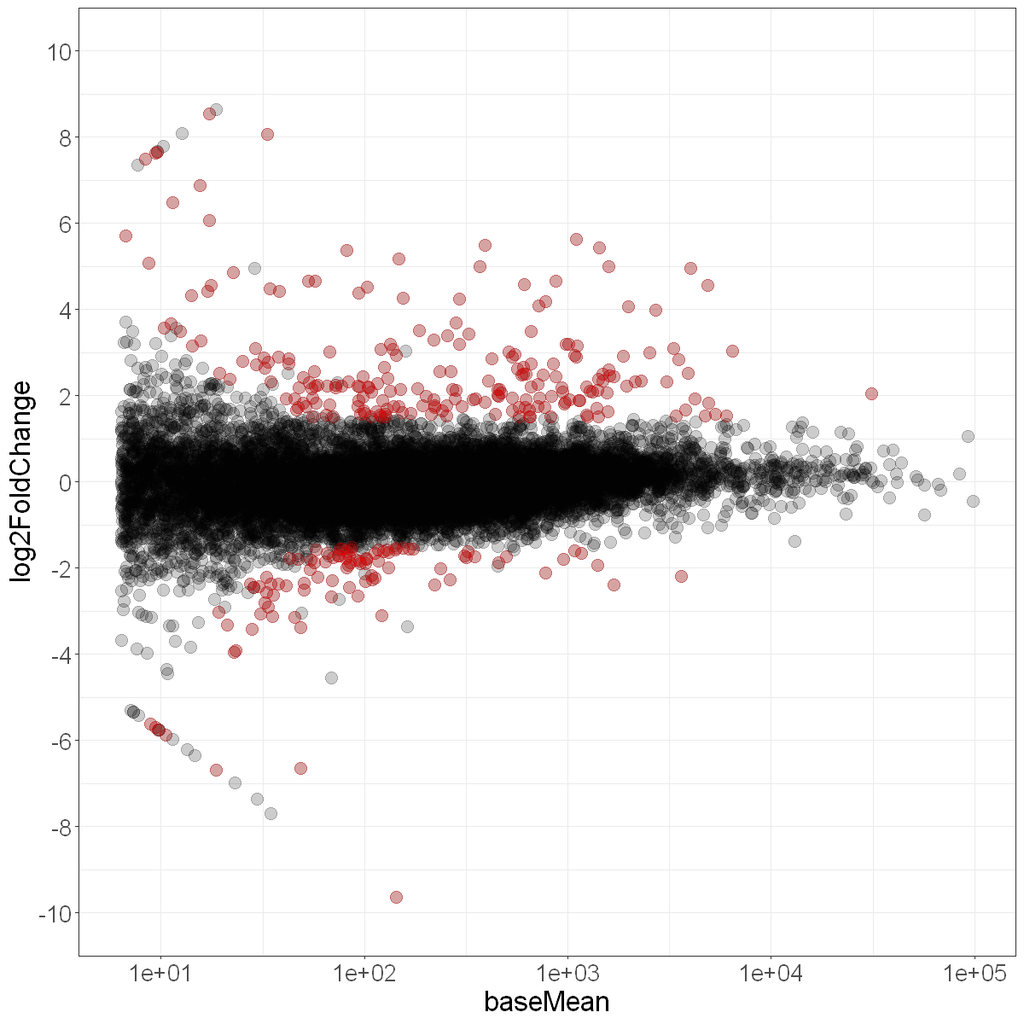

```r
# Adjust our plot window size according to the expected output
options(repr.plot.width=10, repr.plot.height=10)

# MA plot! Need to select based on a fold change > x and padj <= fdr
# Usually FC = 1.5, fdr = 0.05

DE_A549_IAV.df %>%
filter(status == "OK") %>%

# 1. Data
ggplot(.) +
    # 2. Aesthetics
    aes(x=baseMean, y = log2FoldChange) +

    # Theme
    theme_bw() +
    theme(text = element_text(size=20)) +

    # 3. Scaling
    # Use a log10 scale on the x axis
    scale_x_log10() +

    # Set the breaks on our y-axis
    scale_y_continuous(limits = c(-10, 10), breaks = seq(-10, 10, 2)) +

    # 4. Geoms
    # Colour our points all in red
    geom_point(colour = "red", alpha = 0.2, size=4, na.rm=TRUE) +

    ### 2.1.2
    # Change it so that only high L2FC with low p-values will be in red, the rest as black
    gghighlight(padj < 0.05, abs(log2FoldChange) > 1.5, unhighlighted_params = list(colour = "black"))
```

## 2.1.3 Interpreting our MA plot

So our plot shows us the general distribution of the DE data. Looking at it, we can see, notably, that it appears that we have many more genes upregulated than downregulated in comparison to our control. We also see, as expected, more low-probability variation occuring with lower normalized mean counts. Conversely, as our overall mean counts increase, we also see less variation in general but we do see a gene that does pass threshold DE with a low enough p-value! To investigate further you could filter the data or look again with a volcano plot!

## 2.2.0 Volcano plots examine fold-change vs p-value

While the MA plots explored data based on its fold-change values in relation to mean expression, the volcano plot looks purely at differential expression based on it's p-value (ie the probability that the DE is real). To emphasize the importance of the p-value we will -log transform it so smaller p-values are higher up on the y-axis. This quickly partitions data points in the visualization to draw high-DE/low p-value combinations away from the bulk of the population.

To plot this data, we'll use our larger `blanco_data_long.df` which contains data from multiple experiments. For now, let's focus on just the SARS-CoV-2 data that has been generated in the A549 host cells. Our -log transformation of the p-values will also be problematic when encountering 0, so be careful! Let's compare plots with and without these problem values.

To label our points of interest, we'll also use the `geom_text_repel()` from the `ggrepel` package. This will help arrange and plot text onto our scatterplot in a way that avoids collisions with the data and the other labels!

```r
# Adjust our plot window size according to the expected output
options(repr.plot.width=20, repr.plot.height=10)

# Remove p-values = 0
volcano.plot1 <-

# Volcano plot!
blanco_data_long.df %>%
filter(pathogen == "SARS-CoV-2", host=="A549", padj !=0) %>%

# 1. Data
ggplot(.) +
    # 2. Aesthetics
    aes(x=L2FC, y = -log10(padj)) +

    # Themes
    theme_bw()+
    theme(text = element_text(size=20)) +
    labs(title = "Volcano plot with p-values == 0 removed") +

    # 4. Geoms
    # points all coloured red
    geom_point(colour = "red", alpha = 0.3, size=4) +

    # highlight leaves only the ones meeting our criteria as red, colour rest as blue
    gghighlight(abs(L2FC) > 2, padj < 0.05, unhighlighted_params = list(colour = "blue")) +

    ### 2.2.0
    # Add labels but only for the top 10 genes
    geom_text_repel(data = blanco_data_long.df %>%
                    filter(pathogen == "SARS-CoV-2", host=="A549", abs(L2FC) > 2, padj !=0) %>%
                    arrange(padj) %>% dplyr::slice(1:10),
                    aes(label = GeneName), size=6)
```

```r
# Adjust our plot window size according to the expected output
options(repr.plot.width=20, repr.plot.height=10)

# leave in p-values = 0
volcano.plot2 <-

# Volcano plot!
blanco_data_long.df %>%
filter(pathogen == "SARS-CoV-2", host=="A549") %>%

# 1. Data
ggplot(.) +
    # 2. Aesthetics
    aes(x=L2FC, y = -log10(padj)) +

    # Themes
    theme_bw()+
    theme(text = element_text(size=20)) +
    labs(title = "Volcano plot with all p-values") +

    # 4. Geoms
    # points all coloured red
    geom_point(colour = "red", alpha = 0.3, size=4) +

    # highlight leaves only the ones meeting our criteria as red, colour rest as blue
    gghighlight(abs(L2FC) > 2, padj < 0.05, unhighlighted_params = list(colour = "blue")) +

    # Add labels but only for the top 10 genes
    geom_text_repel(data = blanco_data_long.df %>%
                    filter(pathogen == "SARS-CoV-2", host =="A549", abs(L2FC) > 2) %>%
                    arrange(padj) %>% dplyr::slice(1:10),
                    aes(label = GeneName), size=6)
```

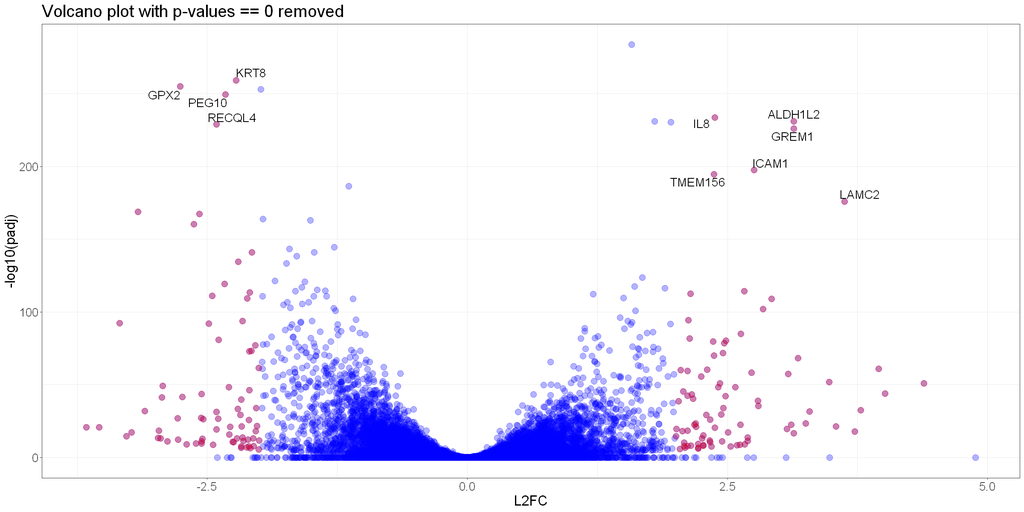

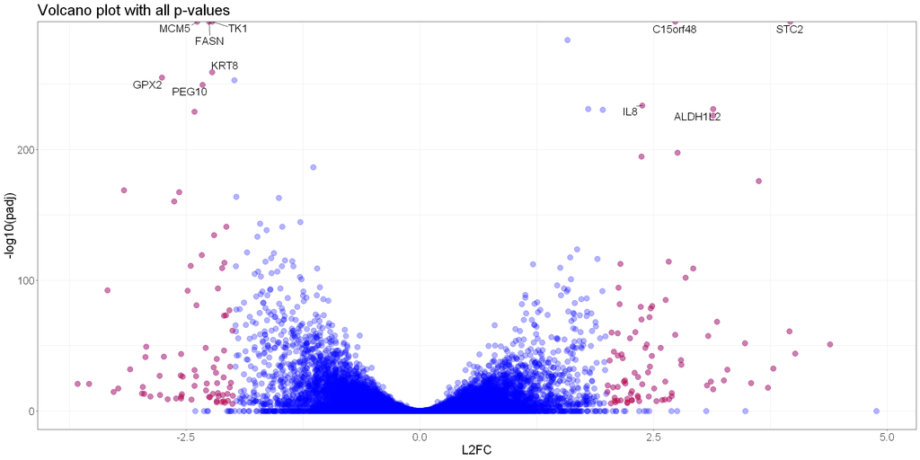

```r
# Plot both of our figures together
fig.show="hold"; out.width="50%"
volcano.plot1
volcano.plot2
```

## 2.3.0 Interpreting your volcano plots

Looking at our volcano plots, we can clearly see the volcano shape we are looking for. The data is split between our $\pm$ log$_{2}$ fold changes with points highlighted when we see DE beyond this. You can customize your parameters but you can also see the emphasis on lower p-values in our data set. The most "significant" data is found in the upper left and right quadrants of the graph, which wasn't made clear in the MA plot. You could use the same tricks to label your MA plot too but the data could end up anywhere along the MA plot.

In the end, if you *do* have access to the original counts, it may be of use to consider this information when further investigating your candidate genes from DE.

## 3.0.0 Medium resolution analysis focuses on groups of genes

Now that we've taken an overall look at our data, we can begin to assess our data based on some candidate genes or hypothesis testing. For instance, you may only be interested in looking at genes with an L2FC > 3. In other cases, you may be interested in a group of genes pertaining to a function like the chemokines which are part of the inflammation response.

After selecting a subset of genes we can begin to compare their DE data more meaningfully across different sample sets. Let's start by generating a list of the highest DE genes with low p-values in the SARS-CoV-2 infection scenario.

```r
# Select the genes we want to visualize
heatmap_gene.list <-
blanco_data_long.df %>%

# filter for data from a specific experiment, and then by high positive L2FC values with low p-values
filter(pathogen == "SARS-CoV-2", host == "A549", L2FC > 3, padj < 0.001) %>%
dplyr::select(GeneName) %>% unlist()

str(heatmap_gene.list)
```

```
 Named chr [1:18] "IL6" "IL1A" "CSF2" "PTX3" "ULBP1" "STC2" "ADM2" "MMP10" ...
 - attr(*, "names")= chr [1:18] "GeneName1" "GeneName2" "GeneName3" "GeneName4" ...
```

## 3.1.0 Use heatmaps to visualize data across a continuous range of values

Now that we have generated a select group of genes to examine, our DE data is well-suited to visualizing in heatmap or heat plot. In our heatplot we can generate values along two categorical axes. On the y-axis we can plot DE values from our individual genes, while on the x-axis we will show values across multiple experiments. To visualize the data itself, we will use the `geom_tile()` command.

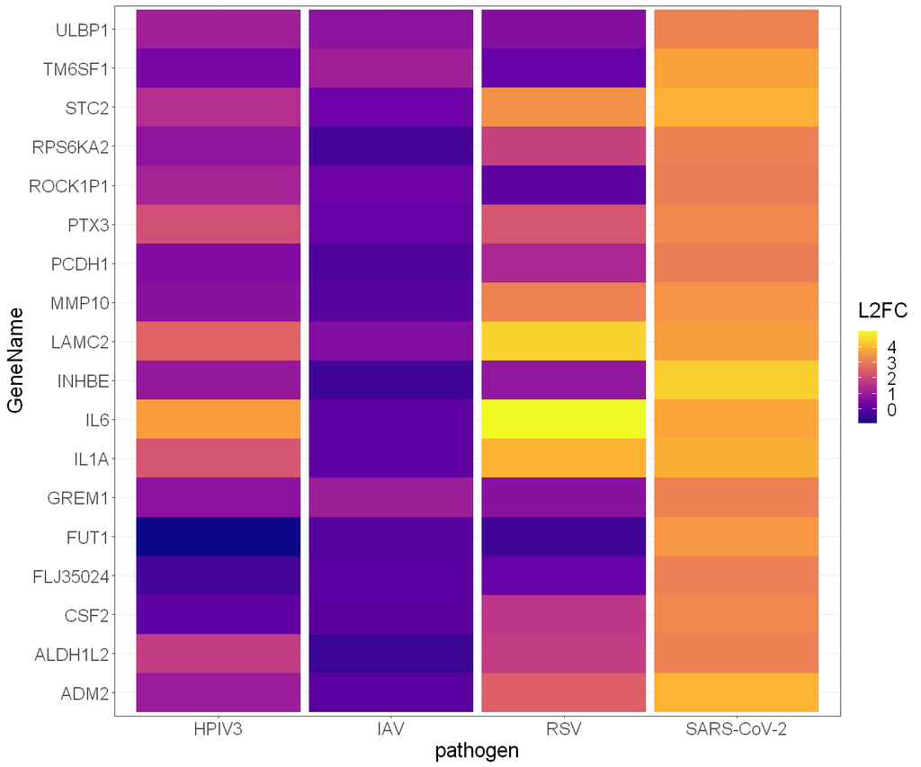

```r
# Adjust our plot window size according to the expected output
options(repr.plot.width=12, repr.plot.height=10)

# heatmap of our data based on a list of top DE genes from the SARS-CoV-2 infection of A549 cells

blanco_data_long.df %>%
filter(GeneName %in% heatmap_gene.list,
         host == "A549"
      ) %>%

# 1. Data
ggplot(.) +
    #2. Aesthetics
    aes(x=pathogen, y = GeneName, fill=L2FC) +

    # Theme
    theme_bw()+
    theme(text = element_text(size=20)
          #axis.text.x = element_text(angle=45, hjust = 1)
         )+

    # 3. Scaling
    scale_fill_viridis_c(option="plasma")+

    # Geoms
    # Use a tile and set the width a little smaller to give a gap between groups
    geom_tile(width=0.95)
```

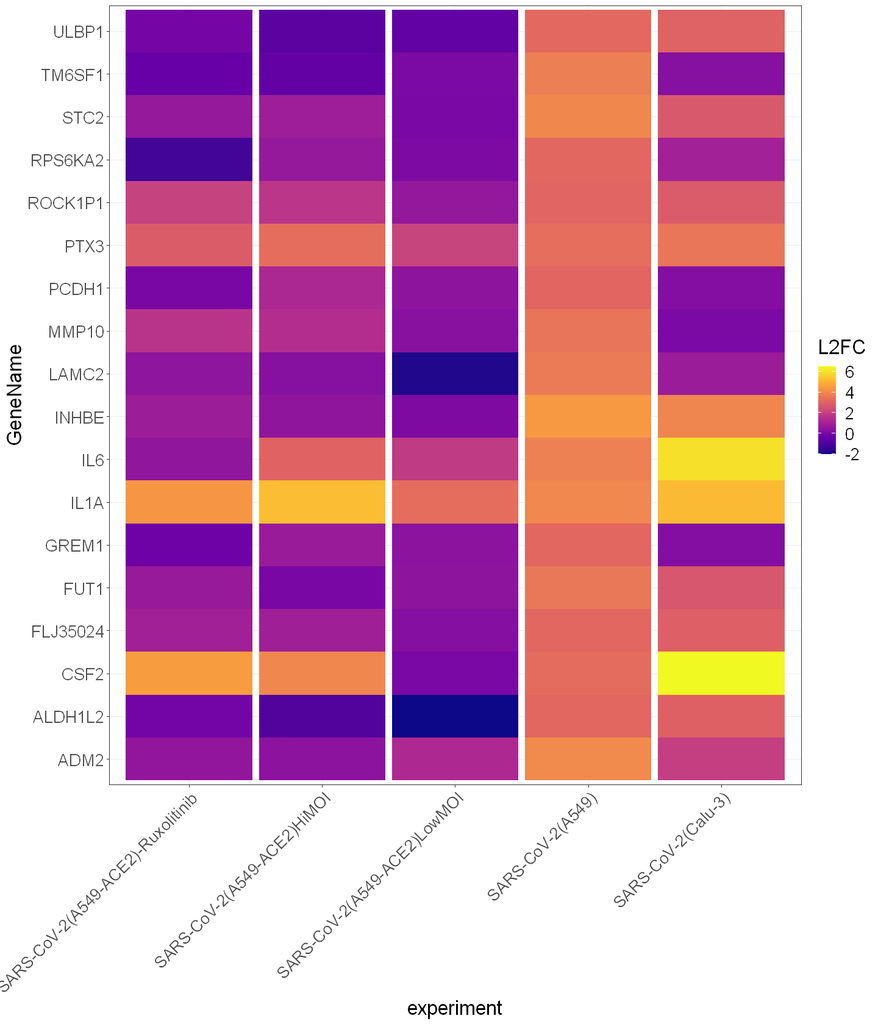

```r
# Adjust our plot window size according to the expected output
options(repr.plot.width=12, repr.plot.height=14)

# heatmap of our data based on a list of top DE genes from the SARS-CoV-2 infection of A549 cells
# Split x-axis by experiment name

blanco_data_long.df %>%
filter(GeneName %in% heatmap_gene.list,
       pathogen == "SARS-CoV-2"
      ) %>%

# 1. Data
ggplot(.) +
    #2. Aesthetics
    aes(x=experiment, y = GeneName, fill=L2FC) +

    # Theme
    theme_bw()+
    theme(text = element_text(size=20),
          axis.text.x = element_text(angle=45, hjust = 1)
         )+

    # 3. Scaling
    scale_fill_viridis_c(option="plasma")+

    # Geoms
    # Use a tile and set the width a little smaller to give a gap between groups
    geom_tile(width = 0.95)
```

## 3.1.1 Interpreting a heatmap of upper values

From our list of the top 18 DE hits in our SARS-CoV-2 set, it looks like we see some similar hits across some of the genes when infecting A549 cells with other viruses like HPIV3 and RSV. We see strong L2FC values for IL6, IL1A and LAMC2 for instance. IL6 (interleukin 6) has been reported to play a role in both mounting an effective immune response to certain viral infections but its interactions with other factors may also have a potential role in the exacerbation of viral phenotypes. In looking across different host cell infections by SARS-CoV-2 there is again consistent upregulation of IL1A and IL6.

Using a similar method, we can instead focus on genes from a specific family or pathway as long as we have a list. Let's try the family of chemokines which play a role in inducing cell movement during the immune reponse.

```r
# Build a list of the potential chemokines by looking for those matching the "CCL" pattern
heatmap_ccl.list <-
blanco_data_long.df %>%

# Filter specifically for any genes that have CCL in their name
filter(str_detect(GeneName, "CCL")) %>%
dplyr::select(GeneName) %>%
unlist() %>%
unique()

str(heatmap_ccl.list)
```

```
 chr [1:29] "CCL5" "CCL4" "CCL22" "CCL20" "CCL3" "CCL2" "CCL1" "CCL11" ...
```

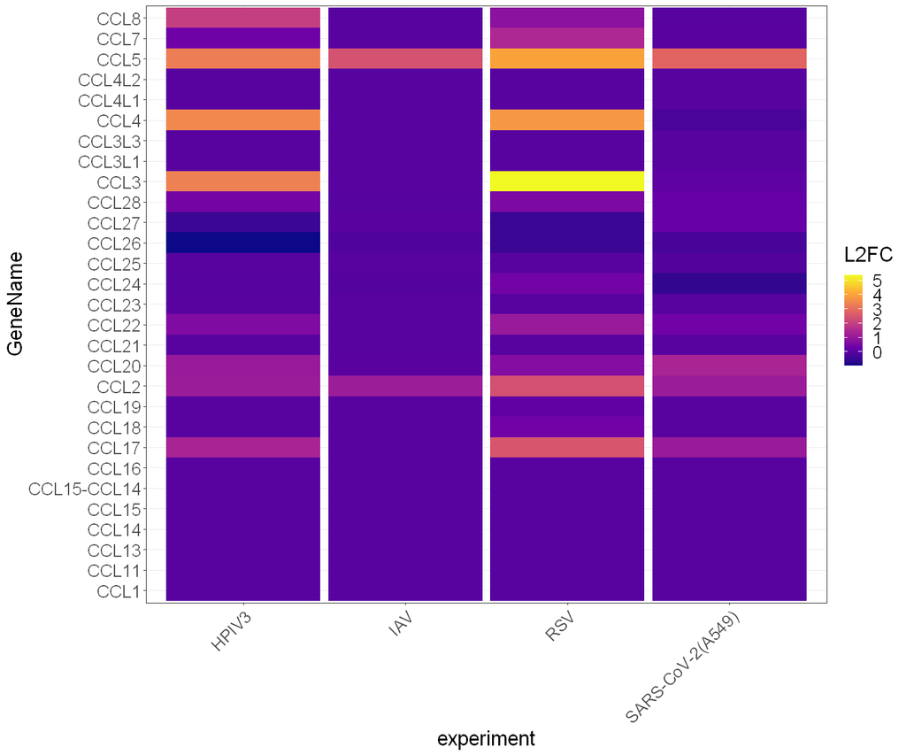

```r
# Adjust our plot window size according to the expected output
options(repr.plot.width=12, repr.plot.height=10)

# heatmap of our data based on a list of chemokine genes

blanco_data_long.df %>%

# Filter for genes in our list, and experiments where the host cell was "A549"
filter(GeneName %in% heatmap_ccl.list,
         host == "A549"
      ) %>%

# 1. Data
ggplot(.) +
    #2. Aesthetics
    aes(x=experiment, y = GeneName, fill=L2FC) +

    # Theme
    theme_bw()+
    theme(text = element_text(size=20),
          axis.text.x = element_text(angle=45, hjust = 1)
         )+

    # 3. Scaling
    scale_fill_viridis_c(option="plasma")+

    # Geoms
    # Use a tile and set the width a little smaller to give a gap between groups
    geom_tile(width = 0.95)
```

## 3.1.2 Heatmap interpretation

From our heatmap, we can see that looking only at the chemokines, we see consistent upregulation of CCL5 and CCL2 when infecting our A459 cells with any of these viruses. In comparison, however, HPIV3 and RSV infection show a much higher DE across the CCL family in comparison to SARS-CoV-2 which appears to illicit less inflamatory response in the time-frame sampled.

## 3.2.0 Looking at single genes with dot plots

We can further narrow our search instead of looking at whole gene groups, and pick a small set of specific genes. We'll use a dotplot to visualize the data where the y-axis positions points based on the L2FC and we'll use a categorical x-axis of gene lists. We'll also group our data in a few ways:

1. We'll scale our point sizes based on the adjusted p-value to get a better sense of how strong/probable these changes are.
2. We'll use shape to define the cell type of our host in each experiment
3. We'll use colour to define the pathogen used in each experiment

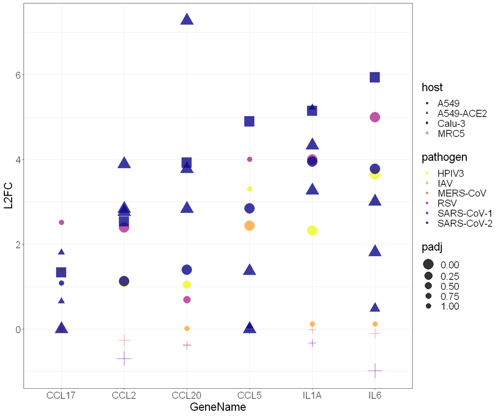

```r
# Adjust our plot window size according to the expected output
options(repr.plot.width=12, repr.plot.height=10)

single_genes = c("CCL5", "CCL2", "CCL20", "CCL17", "IL6", "IL1A")

blanco_data_long.df %>%
filter(GeneName %in% single_genes,
      ) %>%

# 1. Data
ggplot(.) +
    # 2. Aesthetics
    aes(x=GeneName, y = L2FC, colour=pathogen, shape=host) +

    # Theme
    theme_bw()+
    theme(text = element_text(size=20)) +

    # 3. Scaling
    scale_colour_viridis_d(option="plasma", direction = -1) +
    # Scale the size range
    scale_size(range = c(8, 4)) +

    # 4. Geoms
    geom_point(aes(size = padj), alpha = 0.8)
```

## 3.2.1 Dot plot interpretation

Focusing on small sets of genes we can see some trends across our groups. For instance, in most host cells, we see a >2 L2FC in CCL2 as a response to infection by SARS-CoV-2. Actually our weakest response to SARS-CoV-2 was seen in the A459 host so our initial heatmap didn't give us a full picture of what might be happening.

If you had access to replicate data, you could perform a similar visualization

## 4.0.0 RNAseq analysis for significant functional terms

Up until this point, we've been feeling our way through the data, rather undirected. Often within manuscripts you will find deeper analyses of differential expression by examining the collection of functional terms to determine trends or pathways of interest. The Gene Ontology (GO) resource represents a codification of gene function through three domains: cellular component, molecular function, and biological process.

Most, if not all, of the genes in our dataset can be described in some way by a GO term. Once we collect these terms, we can begin to look for meaningful groups that could be considered over-represented (or under-represented) in our dataset. Once we have collected this information we can visualize it similar to our individual gene dotplots.

## 4.1.0 Use the `goseq` package to pull down GO terms for your genes

Using the `goseq` package we can perform a full GO term analysis on our DE data with an analysis for enriched terms within our set of over or underexpressed genes. However, in order to begin the process of pulling down go terms, with the `goseq` package, we also need to generate a named integer vector to split our gene sets into the two relevant categories.

We'll store our categorized set of genes in `genes_SARS_CoV_2` where a 1 represents over/underexpressed genes in our set, and 0 represents all remaining genes.

```r
# Set up the gene information we need for the GO-term analysis
# It needs to know which genes meet our FC criteria and which do not
#nrow(blanco_data.df)

# Casting our logical as an integer will create a 0/1 matrix
genes_SARS_CoV_2 <- as.integer(blanco_data.df$`padj_SARS-CoV-2(A549)` < 0.05 & # low p-value
                               abs(blanco_data.df$`SARS-CoV-2(A549)_L2FC`) > 1.5) # absolute L2FC > 1.5

# We'll name each element in our vector by the gene names
names(genes_SARS_CoV_2) = blanco_data.df$GeneName

# What is our object?
str(genes_SARS_CoV_2)

# Summarize our vector
table(genes_SARS_CoV_2)
```

```
 Named int [1:23710] 0 0 0 0 0 1 0 0 1 0 ...
 - attr(*, "names")= chr [1:23710] "IFNL1" "IFNL2" "IFNL3" "IFNB1" ...
```

```
genes_SARS_CoV_2
    0     1
23232   478
```

## 4.1.1 Choose the correct database to map your gene symbols to GO terms

```r
# Pull down the supported organisms and look for the human "hg19" genome
supportedOrganisms() %>%
filter(Genome == "hg19")
```

A data.frame: 3 × 5

| Genome <chr> | Id <chr> | Id Description <chr> | Lengths in geneLeneDataBase <lgl> | GO Annotation Available <lgl> |
| --- | --- | --- | --- | --- |
| hg19 | knownGene | Entrez Gene ID | TRUE | TRUE |
| hg19 | ensGene | Ensembl gene ID | TRUE | TRUE |
| hg19 | geneSymbol | Gene Symbol | TRUE | TRUE |

## 4.1.2 Fitting a probability weighting function (PWF) to our dataset

Looking at our table above we can immediately see the information we're looking for in the third row. Using the gene symbols in our data, we can

1. Map our gene symbols to GO annotations, and
2. We can calculate gene lengths.

The second portion of information is required in the generation of a probability weighting function. This PWF will determine a weighting for each gene based on it's length as this information can influence our enrichment analysis.

We'll use the `nullp()` function to generate the PWF for our dataset.

```
Loading hg19 length data...

Warning message in pcls(G):
"initial point very close to some inequality constraints"
```

A data.frame: 6 × 3

|  | DEgenes <int> | bias.data <dbl> | pwf <dbl> |
| --- | --- | --- | --- |
| IFNL1 | 0 | NA | NA |
| IFNL2 | 0 | NA | NA |
| IFNL3 | 0 | NA | NA |
| IFNB1 | 0 | 840 | 0.01479968 |
| IFNL4 | 0 | NA | NA |
| CCL5 | 1 | 1230 | 0.01943073 |

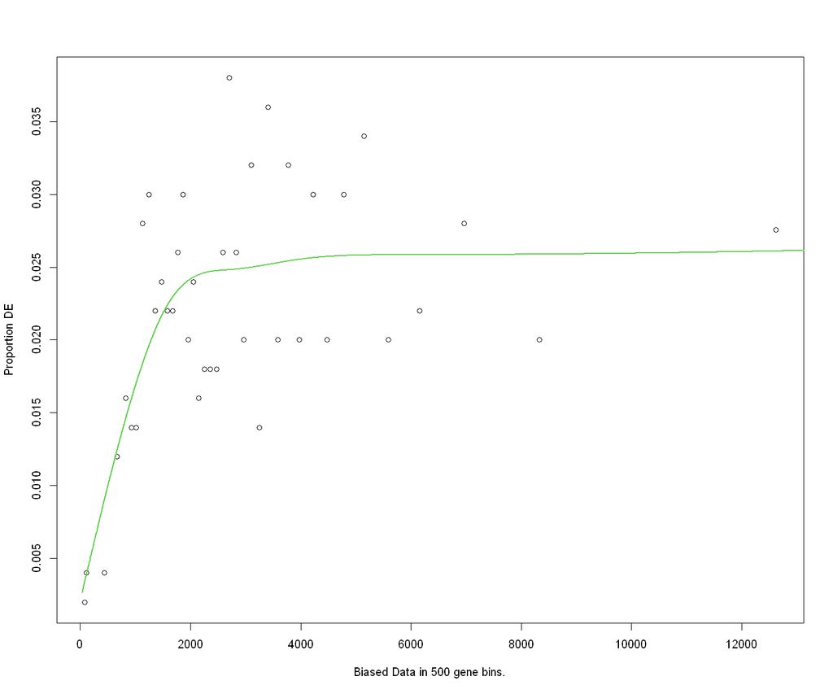

```r
# Generate the PWF for our vector of genes
pwf_SARS_CoV_2 <- nullp(genes_SARS_CoV_2, "hg19", "geneSymbol")

head(pwf_SARS_CoV_2)
```

## 4.1.3 Generate over and under-expressed GO terms from our DE data

We're now ready to query the GO database for over and underexpressed terms in our data. We'll use the `goseq()` command to do this, providing our PWD data as well as the correct database information. The default method used in this process to generate our enrichment analysis is the Wallenius approximation. You can choose to use random sampling but this method can take much longer with little difference in results.

For more information on this process see the `goseq` package vignette [here](https://bioconductor.org/packages/devel/bioc/vignettes/goseq/inst/doc/goseq.pdf)

```r
# Generate our go enrichment analysis
GO.wall_SARS_CoV_2 <- goseq(pwf_SARS_CoV_2, "hg19", "geneSymbol")

head(GO.wall_SARS_CoV_2)
```

```
Fetching GO annotations...

For 5229 genes, we could not find any categories. These genes will be excluded.

To force their use, please run with use_genes_without_cat=TRUE (see documentation).

This was the default behavior for version 1.15.1 and earlier.

Calculating the p-values...
```

A data.frame: 6 × 7

|  | category <chr> | over_represented_pvalue <dbl> | under_represented_pvalue <dbl> | numDEInCat <int> | numInCat <int> | term <chr> | ontology <chr> |
| --- | --- | --- | --- | --- | --- | --- | --- |
| 3050 | GO:0006261 | 2.864576e-10 | 1 | 20 | 142 | DNA-dependent DNA replication | BP |
| 1621 | GO:0003688 | 2.304593e-09 | 1 | 9 | 23 | DNA replication origin binding | MF |
| 267 | GO:0000727 | 3.831010e-09 | 1 | 7 | 12 | double-strand break repair via break-induced replication | BP |
| 4006 | GO:0008283 | 7.782412e-09 | 1 | 83 | 1967 | cell population proliferation | BP |
| 10685 | GO:0042127 | 2.074005e-08 | 1 | 73 | 1694 | regulation of cell population proliferation | BP |
| 3057 | GO:0006270 | 2.357825e-08 | 1 | 10 | 39 | DNA replication initiation | BP |

```r
# What is the structure of our resulting data?
str(GO.wall_SARS_CoV_2)
```

```
'data.frame':	22531 obs. of  7 variables:
 $ category                : chr  "GO:0006261" "GO:0003688" "GO:0000727" "GO:0008283" ...
 $ over_represented_pvalue : num  2.86e-10 2.30e-09 3.83e-09 7.78e-09 2.07e-08 ...
 $ under_represented_pvalue: num  1 1 1 1 1 ...
 $ numDEInCat              : int  20 9 7 83 73 10 24 136 6 99 ...
 $ numInCat                : int  142 23 12 1967 1694 39 259 4174 12 2649 ...
 $ term                    : chr  "DNA-dependent DNA replication" "DNA replication origin binding" "double-strand break repair via break-induced replication" "cell population proliferation" ...
 $ ontology                : chr  "BP" "MF" "BP" "BP" ...
```

## 4.2.0 Interpreting our `goseq` results

Looking at the results of our analysis, we are returned a listing of 22,531 GO terms across the 3 domains (CC, BP, and MF). We are given two sets of p-values, one each for over-represented and under-represented terms. With each term we also see how many times that term is represented in our DE data vs the total number of times that term may appear in the GO database we queried. As you can see from the first few rows of data, some GO term categories can encompass a large number of genes.

To begin our analysis we can filter the enriched GO terms sets by applying a multiple hypothesis test correction with `p.adjust()` using the Benjamini-Hochberg method.

```r
# Generate an enriched Go term dataset
enriched.GO_SARS_CoV_2 <-
# Adjust the p-values of the over-represented column
GO.wall_SARS_CoV_2[p.adjust(GO.wall_SARS_CoV_2$over_represented_pvalue, method="BH") < 0.05, ]

# How many terms come back from our filtering?
str(enriched.GO_SARS_CoV_2)
```

```
'data.frame':	84 obs. of  7 variables:
 $ category                : chr  "GO:0006261" "GO:0003688" "GO:0000727" "GO:0008283" ...
 $ over_represented_pvalue : num  2.86e-10 2.30e-09 3.83e-09 7.78e-09 2.07e-08 ...
 $ under_represented_pvalue: num  1 1 1 1 1 ...
 $ numDEInCat              : int  20 9 7 83 73 10 24 136 6 99 ...
 $ numInCat                : int  142 23 12 1967 1694 39 259 4174 12 2649 ...
 $ term                    : chr  "DNA-dependent DNA replication" "DNA replication origin binding" "double-strand break repair via break-induced replication" "cell population proliferation" ...
 $ ontology                : chr  "BP" "MF" "BP" "BP" ...
```

```r
# What kind of terms do we see in our enrichment?
enriched.GO_SARS_CoV_2$term
```

1. 'DNA-dependent DNA replication'

2. 'DNA replication origin binding'

3. 'double-strand break repair via break-induced replication'

4. 'cell population proliferation'

5. 'regulation of cell population proliferation'

6. 'DNA replication initiation'

7. 'DNA replication'

8. 'extracellular region'

9. 'MCM complex'

10. 'cellular response to organic substance'

11. 'response to stress'

12. 'pre-replicative complex assembly involved in nuclear cell cycle DNA replication'

13. 'pre-replicative complex assembly'

14. 'pre-replicative complex assembly involved in cell cycle DNA replication'

15. 'cellular response to chemical stimulus'

16. 'cell cycle'

17. 'cell cycle G1/S phase transition'

18. 'cell cycle DNA replication'

19. 'G1/S transition of mitotic cell cycle'

20. '3\'-5\' DNA helicase activity'

21. 'positive regulation of cell population proliferation'

22. 'cytokine-mediated signaling pathway'

23. 'extracellular space'

24. 'cellular response to biotic stimulus'

25. 'response to organic substance'

26. 'cell cycle process'

27. 'blood vessel development'

28. 'vasculature development'

29. 'regulation of extrinsic apoptotic signaling pathway in absence of ligand'

30. 'nuclear DNA replication'

31. 'cholesterol biosynthetic process via desmosterol'

32. 'cholesterol biosynthetic process via lathosterol'

33. 'cellular response to lipopolysaccharide'

34. 'negative regulation of signal transduction in absence of ligand'

35. 'negative regulation of extrinsic apoptotic signaling pathway in absence of ligand'

36. 'mitotic cell cycle process'

37. 'response to cytokine'

38. 'cellular response to cytokine stimulus'

39. 'enzyme linked receptor protein signaling pathway'

40. 'DNA unwinding involved in DNA replication'

41. 'growth factor receptor binding'

42. 'cellular response to molecule of bacterial origin'

43. 'steroid metabolic process'

44. 'mitotic DNA replication'

45. 'epithelial cell differentiation'

46. 'extracellular matrix organization'

47. 'extracellular structure organization'

48. 'sterol metabolic process'

49. 'alcohol metabolic process'

50. 'cholesterol biosynthetic process'

51. 'secondary alcohol biosynthetic process'

52. 'positive regulation of cellular component movement'

53. 'response to chemical'

54. 'regulation of nucleotide-binding oligomerization domain containing signaling pathway'

55. 'cholesterol metabolic process'

56. 'signal transduction in absence of ligand'

57. 'extrinsic apoptotic signaling pathway in absence of ligand'

58. 'tissue development'

59. 'positive regulation of vasculature development'

60. 'positive regulation of cell motility'

61. 'sterol biosynthetic process'

62. 'single-stranded DNA helicase activity'

63. 'cellular modified amino acid catabolic process'

64. 'positive regulation of cell migration'

65. 'cell surface receptor signaling pathway'

66. 'secondary alcohol metabolic process'

67. 'positive regulation of locomotion'

68. 'DNA helicase activity'

69. 'organic hydroxy compound biosynthetic process'

70. 'protein kinase B signaling'

71. 'catalytic activity, acting on DNA'

72. 'alcohol biosynthetic process'

73. 'DNA metabolic process'

74. 'organic hydroxy compound metabolic process'

75. 'mitotic cell cycle'

76. 'receptor regulator activity'

77. 'regulation of transcription involved in G1/S transition of mitotic cell cycle'

78. 'regulation of cell cycle'

79. 'steroid biosynthetic process'

80. 'regulation of nucleotide-binding oligomerization domain containing 2 signaling pathway'

81. 'fibroblast growth factor-activated receptor activity'

82. 'nucleotide-binding oligomerization domain containing signaling pathway'

83. 'inflammatory response'

84. 'response to lipopolysaccharide'

## 4.2.1 Plot our enriched GO term categories as a dot plot

Looking at our enriched set of go terms, we see terms like `inflammatory response` and `response to stress`. Now that we have a set of enriched GO terms, we can filter and plot this information as a dotplot with the following characteristics:

1. GO terms listed along the y-axis
2. size of dots representing category size
3. use colour to represent the % of DE genes present from that that category

Let's look at terms that include the word "response".

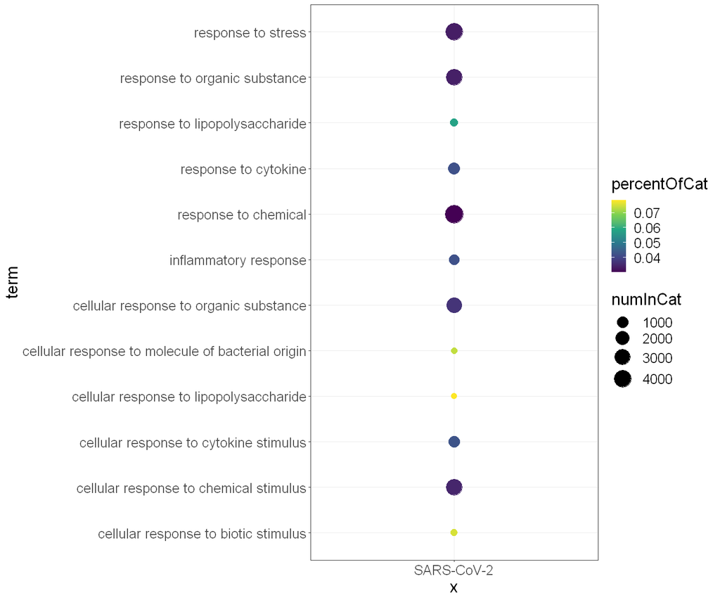

```r
# Adjust our plot window size according to the expected output
options(repr.plot.width=12, repr.plot.height=10)

enriched.GO_SARS_CoV_2 %>%

# Generate an percentage value
mutate(percentOfCat = numDEInCat/numInCat,
       pathogen = "SARS-CoV-2") %>%

# Filter for only terms that include the word "response"
filter(str_detect(term, "response")) %>%

# 1. Data
ggplot(.) +
    # 2. Aesthetics
    aes(x="SARS-CoV-2", y=term, size=numInCat, colour = percentOfCat) +

    # Theme
    theme_bw() +
    theme(text = element_text(size=20)) +

    # 3. Scaling
    scale_size(range=c(3,10)) +
    scale_colour_viridis_c() +

    # 4. Geoms
    geom_point()
```

## 4.2.2 Plot multiple conditions to the same dot plot

With a little bit of elbow grease, we can generate a data frame with multiple GO enrichment analyses for multiple experiments and now we can compare enrichment across data sets!

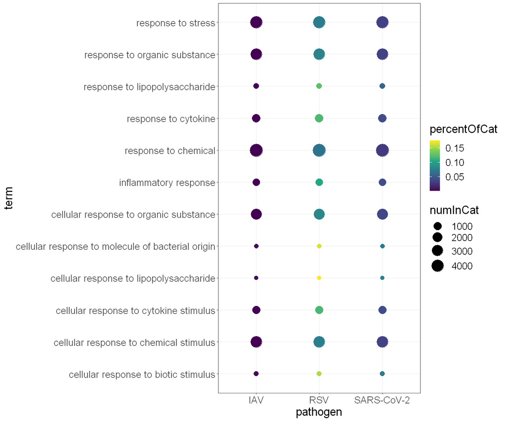

```r
# Load up a combined enrichment analysis
load("./data/Lecture04.RData")

enriched.GO_combined.df %>%

# 1. Data
ggplot(.) +
    # 2. Aesthetics
    aes(x=pathogen, y=term, size=numInCat, colour = percentOfCat) +

    # Theme
    theme_bw() +
    theme(text = element_text(size=20)) +

    # 3. Scaling
    scale_size(range=c(3,10)) +
    scale_colour_viridis_c() +

    # 4. Geoms
    geom_point()
```

## 4.3.0 Upset plots

## 4.3.1 Can Upset plots help us to make sense of overlapping relationships?

`UpSetR`: https://github.com/hms-dbmi/UpSetR

Upset plots are an alternative to Venn diagrams that show the intersection of sets, as well as the size of the sets. Additionally, Venn diagrams can be difficult to interpret for greater than 2 or 3 sets. This is a real life figure from BMC Bioinformatics. Sure it looks pretty, but what does the number 24 represent in this picture in terms of A, B, C, D, and E?

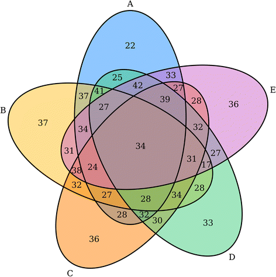

## 4.3.2 Working with `UpsetR` to visualize overlapping datasets

Let's see how UpSet plots work practically. We can compare our data from `blanco_data_long.df` and compare the overlap of DE genes (after filtering or not). To do this in a practical sense, we again need to convert our values to a more boolean system after some more data wrangling. Let's look at our data structure again.

```r
head(blanco_data_long.df)
```

A tibble: 6 × 7

| GeneName <chr> | experiment <chr> | exp_info <chr> | pathogen <chr> | host <chr> | L2FC <dbl> | padj <dbl> |
| --- | --- | --- | --- | --- | --- | --- |
| IFNL1 | SARS-CoV-1 | SARS-CoV-1_MRC5 | SARS-CoV-1 | MRC5 | 0.000000 | 1.00e+00 |
| IFNL1 | IAV | IAV_A549 | IAV | A549 | 1.369700 | 1.00e+00 |
| IFNL1 | MERS-CoV | MERS-CoV_MRC5 | MERS-CoV | MRC5 | 0.000000 | 1.00e+00 |
| IFNL1 | HPIV3 | HPIV3_A549 | HPIV3 | A549 | 7.837988 | 2.62e-68 |
| IFNL1 | RSV | RSV_A549 | RSV | A549 | 7.142762 | 4.51e-44 |
| IFNL1 | SARS-CoV-2(Calu-3) | SARS-CoV-2_Calu-3 | SARS-CoV-2 | Calu-3 | 7.239900 | 2.53e-139 |

```r
# filter for upregulated genes in our SARS-CoV-2/A549 data set and make a list of gene names
SARS_CoV_2.list <-
blanco_data_long.df %>%

# Filter our data
filter(pathogen == "SARS-CoV-2", host == "A549", L2FC >= 2, padj <0.05) %>%

# Select just our gene names
dplyr::select(GeneName) %>%
unlist() %>%
as.character()
```

```r
# Generate our upset data
blanco_upset.df <-
blanco_data_long.df %>%

# Filter our data list using our genes of interest
filter(GeneName %in% SARS_CoV_2.list) %>%

# convert our L2FC data to a logical based on a value of >2
mutate(upregulated = as.double(L2FC >= 2)) %>%

# Select just the gene names, experiments, and the logical variable
dplyr::select(GeneName, experiment, upregulated) %>%

# Pivot our data wide so that each experiment is now a row, each gene is a column
pivot_wider(names_from = experiment, values_from = upregulated) %>%
as.data.frame()

str(blanco_upset.df)
```

```
'data.frame':	87 obs. of  11 variables:
 $ GeneName                         : chr  "CCL5" "ICAM1" "GBP4" "FYN" ...
 $ SARS-CoV-1                       : num  0 0 0 0 0 0 0 0 0 0 ...
 $ IAV                              : num  1 0 0 0 0 0 0 0 0 0 ...
 $ MERS-CoV                         : num  0 0 0 0 0 0 0 0 0 0 ...
 $ HPIV3                            : num  1 0 1 0 1 1 0 0 1 0 ...
 $ RSV                              : num  1 1 1 0 1 1 1 1 0 0 ...
 $ SARS-CoV-2(Calu-3)               : num  1 1 1 0 1 1 1 1 0 0 ...
 $ SARS-CoV-2(A549)                 : num  1 1 1 1 1 1 1 1 1 1 ...
 $ SARS-CoV-2(A549-ACE2)LowMOI      : num  0 1 0 0 0 1 0 0 1 0 ...
 $ SARS-CoV-2(A549-ACE2)HiMOI       : num  0 0 1 0 1 1 0 1 1 0 ...
 $ SARS-CoV-2(A549-ACE2)-Ruxolitinib: num  0 0 0 0 0 1 0 1 1 0 ...
```

## 4.3.3 Generating our upset data

As you can see from our data transformations, we now have all of our experiments listed in columns, with each gene represented in each row. As we look down each column we see a value of 1 or 0 used to differentiate if there was overexpression of that gene in that specific experimental context.

If we had not filtered based on some set of genes, we would have a data frame with more than 23K columns! Now that we have our genes presented in this way we can proceed to generate an upset plot.

Some of the parameters we will set include `nsets` as there are 10 experiments we will use this value, and `nintersects` of which there are many combinations, we'll look at just the top 15 group combinations.

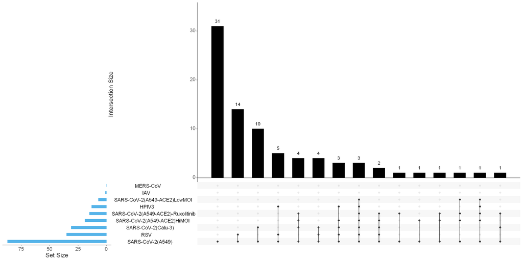

```r
# Load our UpSetR library
#library(UpSetR)

# Adjust our plot window size according to the expected output
options(repr.plot.width=20, repr.plot.height=10)

# Generate our upset plot
upset(blanco_upset.df, nsets=10,
      empty.intersections = TRUE,
      order.by = "freq",
      nintersects = 15,
      main.bar.color = "black",
      sets.bar.color = "#56B4E9",
      text.scale = 2
     )
```

## 4.3.4 Interpreting our Upset plot

From our upset plot, we can see there are 3 regions.

1. The left-hand barplot denotes the number of observations in each set/category.
2. The bottom plot graphically represents the different combinations of each category up to `nintersects`.
3. The upper barplot displays the number of occurences for the combination diplayed in the bottom plot.

From our set sizes, it looks like a L2FC value of > 2 was perhaps too stringent for the IAV and MERS-CoV DE data. Since we did filter our genes initially by the best hits in our SARS-COV-2(A549) dataset, we can see that it has the highest frequency group at 31 genes with over expression in just this set. The next largest overlapping set is of 14 genes between the SARS-CoV-2(A549) set and the RSV(A549) DE data.

You can also see from the plot that there are only 9 combinations of datasets with any real overlap. The remainder of the grouping combinations contain just a single gene in each.

Overall this can make for a simplified interpretation of overlapping genes versus more complicated Venn diagrams!

## 5.0.0 Class summary

Today we took a long look at some popular visualizations for expression data sets generated by an experiment like RNAseq. Our analyses focused more on highlighting aspects of the differential expression information itself from a big-picture low-resolution view like volcano plots to zooming down to the individual gene level with dot plots.

Next week we'll look at examples of "big" data from an even broader sense by trying to generate network diagrams and classifying our datasets into groups with methods like principle component analysis.

## 6.0.0 Weekly assignment

This week's assignment will be found under the current lecture folder under the "assignment" subfolder. It will include a Jupyter notebook that you will use to produce the code and answers for this week's assignment. Please provide answers in markdown or code cells that immediately follow each question section.

|  | Assignment breakdown |  |
| --- | --- | --- |
| Code | 50% | - Does it follow best practices? |
|  |  | - Does it make good use of available packages? |
|  |  | - Was data prepared properly |
| Answers and Output | 50% | - Is output based on the correct dataset? |
|  |  | - Are groupings appropriate |
|  |  | - Are correct titles/axes/legends correct? |
|  |  | - Is interpretation of the graphs correct? |

Since coding styles and solutions can differ, students are encouraged to use best practices. Assignments *may* be rewarded for well-coded or elegant solutions.

You can save and download the Jupyter notebook in its native format. Submit this file to the the appropriate assignment section by 12pm on the date of our next class: April 15th, 2021.

## 7.0.0 References

Sankey diagram documentation: https://www.rdocumentation.org/packages/networkD3/versions/0.4/topics/sankeyNetwork

`riverplot`, another package for making your Sankey diagrams: https://cran.r-project.org/web/packages/riverplot/riverplot.pdf

MA plots directly from two sets of expression data: https://rpkgs.datanovia.com/ggpubr/reference/ggmaplot.html